# DS_Opt slides

## Machine Learning for Engineering

## Dynamical System: Optimization

### Instructor: Daning Huang

$$ \newcommand\norm[1]{{\left\lVert #1 \right\rVert}} \newcommand\ddf[2]{\frac{\mathrm{d} #1}{\mathrm{d} #2}} \newcommand\ppf[2]{\frac{\partial #1}{\partial #2}} \newcommand{\bR}{\mathbb{R}} \newcommand{\vX}{\mathbf{X}} \newcommand{\vtL}{\boldsymbol{\Lambda}} \newcommand{\cB}{\mathcal{B}} \newcommand{\cD}{\mathcal{D}} \newcommand{\cJ}{\mathcal{J}} \newcommand{\cL}{\mathcal{L}} \newcommand\rd[1]{\color{red}{\delta #1}} \newcommand\bd[1]{\color{blue}{\delta #1}} \newcommand\gd[1]{\color{green}{\delta #1}} \newcommand{\dudq}{\color{red}{u_\theta}} \newcommand{\dLdq}{\ddf{\cL}{\theta}} $$

## TODAY: Dynamical System

- Optimization constrained by differential equations (DEs)
- Learning with DE-constrained optimization

### References

- [A tutorial from Stanford](https://cs.stanford.edu/~ambrad/adjoint_tutorial.pdf)

## DE-Constrained Optimization

DE - differential equations

So far we focused on objectives and constraints as **functions**, which does not involve derivatives of unknowns.

Now let's deal with the case where objectives and constraints are function**al**s, which are "functions" of functions.

Formally, define $$ \begin{array}{ll} \mbox{minimize}_{\theta} & \cJ[u;x;\theta] \\ \mbox{subject to} & \cD[u;x;\theta]=f(x;\theta) \\ & \cB[u;x;\theta]=g(x;\theta)\mbox{ on }\partial\Omega \\ & x\in\Omega \end{array} $$ where $x$ is the coordinate, $u(x)$ is a function, and $\theta$ is the design variable.

$\cJ$, $\cD$, $\cB$ are functionals.

## Example - Part I

Suppose $u(x)$ is the solution of the following DE on $\Omega=[0,1]$ $$ p u' - u'' = x^2+\theta_1 x+\theta_2,\quad u(0)=u_0,\ u'(1)=n_1 $$ and the goal is to minimize an integral on $\Omega$ $$ \int_0^1 u(x)^2 dx $$

Then

$\cJ[u;x;\theta]=\int_0^1 u(x)^2 dx$

$\cD[u;x;\theta]=p u' - u''$, $f(x;\theta)=x^2+\theta_1 x+\theta_2$

$\cB_1[u;x;\theta]=u(0)$, $g_1(x;\theta)=u_0$

$\cB_2[u;x;\theta]=u'(1)$, $g_2(x;\theta)=n_1$

## Finding Gradients by Adjoint

Recall in regular equality-constrained optimization, $$ \begin{array}{ll} \mbox{minimize}_{\theta} & J(\theta) \\ \mbox{subject to} & D(\theta)=0 \end{array} $$ with Lagrangian $L(\theta,\lambda)=J(\theta)+\lambda D(\theta)$, the gradient $$ \dLdq = J_\theta(\theta)+\lambda D_\theta(\theta) $$ gives the direction to decrease $J$ **while** satisfying the constraints.

Then with $\dLdq$ we can do gradient descent to minimize $J(\theta)$.

> We will do the same for DE-constrained problems.

To handle the DE-constraints, we first extend the concept of the Lagrange multiplier to a **continuous** version, $\lambda(x)$

Define Lagrangian ($x$ omitted) $$ \cL[u,\lambda;\theta] = \cJ[u;\theta] + \int_{\Omega} \lambda (\cD[u;\theta]-f(\theta)) dx + \int_{\partial\Omega} \lambda (\cB[u;\theta]-g(\theta)) dx $$

We still want $\nabla_\theta\cL$, but the complication is that $u$ depends on $\theta$, which requires a chain-rule-like operation.

Then, for example, for the $\cJ$ part, formally we need: $$ \ddf{}{\theta}\cJ[u;\theta] = \cJ_u \dudq + \cJ_\theta $$

But $u$ is a DE solution that can be expensive to obtain, then $\dudq$ is non-trivial to compute.

> $\cJ_u$ is not an "innocent" term. For now "pretend" it is.

By stationarity condition, we need $$ \cL_u = 0 $$ which translates to $$ \cJ_u[u;\theta] + \int_{\Omega} \lambda \cD_u[u;\theta] dx + \int_{\partial\Omega} \lambda \cB_u[u;\theta] dx = 0 $$

This would produce a DE for $\lambda$. This is the so-called **adjoint** equation.

> We will see a specific example soon.

Now we let's compute $\dLdq$. Its three terms are

$$ \begin{align*} \ddf{}{\theta}\cJ[u;\theta] &= \cJ_u[u;\theta] \dudq + \cJ_\theta[u;\theta] \\ \ddf{}{\theta}\int_{\Omega} \lambda (\cD[u;\theta]-f(\theta)) dx &= \int_{\Omega} \lambda \left( \cD_u[u;\theta]\dudq + \cD_\theta[u;\theta] - f_\theta(\theta) \right) dx \\ \ddf{}{\theta}\int_{\partial\Omega} \lambda (\cB[u;\theta]-g(\theta)) dx &= \int_{\partial\Omega} \lambda \left( \cB_u[u;\theta]\dudq - g_\theta(\theta) \right) dx \end{align*} $$

Those involving $\dudq$ sum to zero, given the **adjoint** solution $\lambda$.

Then the gradient simplifies to $$ \dLdq = \cJ_\theta[u;\theta] + \int_\Omega \lambda \left( \cD_\theta[u;\theta] - f_\theta(\theta) \right) dx - \int_{\partial\Omega} \lambda g_\theta(\theta) dx $$

## Example - Part II

Back to our example. The Lagrangian looks like the following

$$ \cL[u,\lambda;\theta] = \underbrace{\int_0^1 u^2 dx}_{\mbox{Objective}} + \underbrace{\int_\Omega \lambda \left(p u' - u'' - (x^2+\theta_1 x+\theta_2)\right) dx}_{\mbox{DE}} + \underbrace{\lambda(0)(u(0)-u_0) + \lambda(1)(u'(1)-n_1)}_{\mbox{BCs}} $$

First we derive the adjoint equation, i.e., $\cL_u = 0$.

But the devil is in the details: What do terms like $\partial u'/\partial u$ even mean?

Here we need a bit **Calculus of Variation**.

We consider some small arbitrary perturbation $\delta u$ to $u$, called **variation**.

Three simple rules:

- $\delta u$ results in changes in function(al)s of $u$, e.g., $$ \delta (u^2) = (u+\delta u)^2 - u^2 = 2u\delta u $$ as $\delta u\rightarrow 0$.
- $\delta$ interchanges with derivative, i.e., $\delta (u') = (\delta u)'$.
- $u+\delta u$ is still solution to the DE. Then the BC's for $\delta u$ must be homogeneous. *For the current problem* $$ \bd{u(0)}=0,\quad \gd{u'(1)}=0 $$

Then for the Lagrangian $$ \begin{align*} \rd{}\cL[u,\lambda;\theta] &= \int_0^1 \rd{}(u^2) dx + \int_0^1 \lambda \rd{}\left(p u' - u'' - (x^2+\theta_1 x+\theta_2)\right) dx \\ &\quad + \lambda(0)\rd{}(u(0)-u_0) + \lambda(1)\rd{}(u'(1)-n_1) \\ &= \int_0^1 2u\rd{u} dx + \int_0^1 \lambda \underbrace{\left(p \rd{}u' - \rd{}u''\right)}_{\mbox{to tackle next}} dx + \underbrace{\lambda(0)\bd{u(0)} + \lambda(1)\gd{u'(1)}}_{=0} \end{align*} $$

For the second integral, using integral by parts, $$ \begin{align*} \int_0^1 \lambda \rd{} u' dx &= \lambda \bd{u} |_0^1 - \int_0^1 \lambda' \rd{u} dx \\ &= \lambda(1) \bd{u}(1) - \int_0^1 \lambda' \rd{u} dx \\ \int_0^1 \lambda \rd{} u'' dx &= \lambda \gd{u'} |_0^1 - \lambda' \bd{u} |_0^1 + \int_0^1 \lambda'' \rd{u} dx \\ &= -\lambda(0) \gd{u'}(0) - \lambda'(1) \bd{u}(1) + \int_0^1 \lambda'' \rd{u} dx \end{align*} $$

Then the variation of Lagrangian becomes $$ \begin{align*} \delta\cL[u,\lambda;\theta] &= \int_0^1 2u\rd{u} dx + p\left[ \lambda(1) \bd{u}(1) - \int_0^1 \lambda' \rd{u} dx \right] \\ &\quad - \left[ -\lambda(0) \gd{u'}(0) - \lambda'(1) \bd{u}(1) + \int_0^1 \lambda'' \rd{u} dx \right] \\ &= \int_0^1 \left(2u - p\lambda' - \lambda'' \right)\rd{u} dx + (p\lambda(1) + \lambda'(1)) \bd{u(1)} + \lambda(0) \gd{u'(0)} \end{align*} $$

The variation $\delta u$ is arbitrary, so for $\delta\cL$ to be zero, we need $$ \begin{align*} \rd{u} &\Rightarrow 2u - p\lambda' - \lambda''=0 \\ \bd{u(1)} &\Rightarrow p\lambda(1) + \lambda'(1) = 0 \\ \gd{u'(0)} &\Rightarrow \lambda(0) \end{align*} $$ This is our **adjoint** equation!

With $\lambda$ known, we can find the gradients for our example: $$ \begin{align*} \dLdq &= \cJ_\theta[u;\theta] + \int_\Omega \lambda \left( \cD_\theta[u;\theta] - f_\theta(\theta) \right) dx - \int_{\partial\Omega} \lambda g_\theta(\theta) dx \\ &= -\int_\Omega \lambda f_\theta(\theta) dx \end{align*} $$

## Example - Part III

Now we solve the optimization numerically.

A minor modification: Suppose we know a solution $u^*$ found at the true parameters $\theta^*$, and want to infer $\theta^*$ from $u^*$, $$ \begin{align*} \min_{\theta} &\quad J(u;\theta) \equiv \int_0^1 (u-u^*)^2 dx \\ \mathrm{s.t.} &\quad p u' - u'' = f(x;\theta),\quad u(0)=u_0,\ u'(1)=n_1 \end{align*} $$

> In `Neural Network - Model Embedding`, we have solved the discrete version of this.

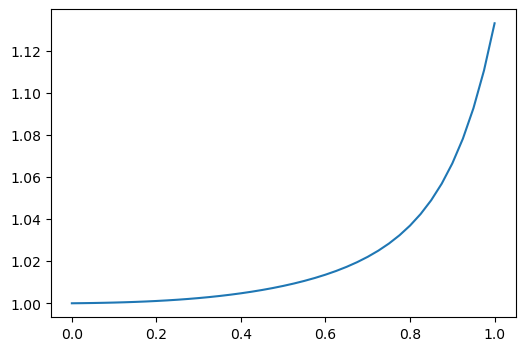

```python
xx = np.linspace(0,1,41)
f = plt.figure(figsize=(6,4))
plt.plot(xx, fu(xx));  # Reference solution, theta=[0,0]
```

First, we solve $u^{(0)}$ at $\theta^{(0)}$. Clearly this is totally off.

```
0.6717312803314148
```

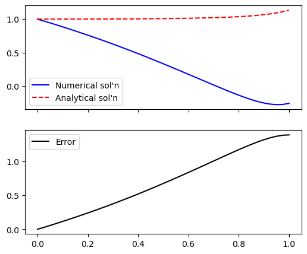

```python
theta0 = [-10.0, -10.0]
sol, mats = galerkin(M, N, p, ub, nb, theta0)
print(obj(sol)[0])
compare_sol(sol, fu, 41);
```

Next, we solve the adjoint equation using Galerkin method.

> See `Math Differential Equation` for more details.

```python
# Adjoint
_, gca = galerkin_ca(sol, mats, obj)    # Adjoint/Backward solve
```

Sanity check to compare with finite difference.

```python
# Finite difference, using a SciPy function
def Jfd(qs):
    sol, _ = galerkin(M, N, p, ub, nb, qs)
    d, _ = obj(sol)
    return d
gfd = approx_fprime(theta0, Jfd)

print(f"Adjoint: {gca}, FD: {gfd}")
```

```
Adjoint: [-0.04238407 -0.09196278], FD: [-0.0423841  -0.09196281]
```

Now let's use a vanilla optimizer from SciPy to solve the problem

```python
def Jca(qs):
    sol, mats = galerkin(M, N, p, ub, nb, qs)
    fun, grd = galerkin_ca(sol, mats, obj)
    return fun, grd
res = minimize(Jca, theta0, method="l-bfgs-b", jac=True)
print(res)
```

```
      fun: 7.84007340724003e-09
 hess_inv: <2x2 LbfgsInvHessProduct with dtype=float64>
      jac: array([2.01907111e-08, 4.43649201e-08])
  message: 'CONVERGENCE: NORM_OF_PROJECTED_GRADIENT_<=_PGTOL'
     nfev: 8
      nit: 4
     njev: 8
   status: 0
  success: True
        x: array([ 0.00033895, -0.0002136 ])
```

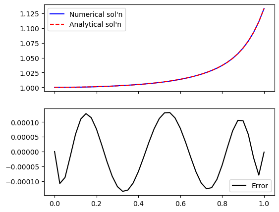

```python
# Check the converged solutions
sol, mats = galerkin(M, N, p, ub, nb, res.x)
compare_sol(sol, fu, 41);
```